# SDS HOMEWORK 3

Jeremy Sapienza & Stefano D’Arrigo

21 Gennaio 2021

$$~$$

# Start with something…

$$~$$

$$~$$

```r
# define a function in order to catch each person and return the correlation matrix between ROIs
get.cor.ROIs <- function(group, person){
  frame <- group[[person]]

  n   <- ncol(frame)
  nms <- names(frame)

  # takes efficiently the combinations, this is useful for large dataset!
  V1  <- rep(nms[1:(n-1)], seq(from=n-1, to = 1, by = -1))
  V2  <- unlist(lapply(1:(n-1), function(i)(nms[(i+1):n])))

  corr.ROIs <- data.frame(ROI_1=V1, ROI_2=V2) # create the correlation in which I will insert the values

  corr.ROIs$z.pearson.corr <- apply(corr.ROIs, 1, function(row) {
    atanh(cor(frame[row["ROI_1"]], frame[row["ROI_2"]])) # takes the sets of columns; apply the Z-transform to the
                                                          # correlation matrix
  })

  return(corr.ROIs)
}
```

$$~$$

Now, for each group create for each corresponding patient the matrix of correlations in the Z-scale.

$$~$$

```r
# create the matrix correlations for all patients
for(person in names(asd_sel)) assign(paste("z.trans.", person, sep=""), get.cor.ROIs(asd_sel, person))
for(person in names(td_sel)) assign(paste("z.trans.", person, sep=""), get.cor.ROIs(td_sel, person))
```

$$~$$

$$~$$

```r
# create a unique matrix for each group
unique.matrix <- function(group) {
  mtx <- z.trans.caltech_0051472[c("ROI_1", "ROI_2")] # create matrix with combinations

  mtx$olymp.mean <- apply(mtx, 1, function(row) {
  values <- c()
  for(person in names(group)) {
     frame <- get(paste("z.trans.", person, sep="")) # match the address of the string with the real variable
     elem <- frame[(frame[["ROI_1"]] == row["ROI_1"]) & (frame[["ROI_2"]] == row["ROI_2"]), "z.pearson.corr"] # select the correlation
     values <- c(values, elem)
  }
    #values <- values[values != min(values)]; values <- values[values != max(values)] # remove the min and max, we have continuous values, so the prob. to have twice the min or max is impossible..
    mean(values) # take the mean!
  })

  return(mtx)
}
```

$$~$$

Now, we call and create the matrix for each group of people as in this way:

$$~$$

```r
# call the creation of unique matrix
asd_sel.dt <- unique.matrix(asd_sel); head(asd_sel.dt)
```

```
##   ROI_1 ROI_2  olymp.mean
## 1  2001  2002  0.45679384
## 2  2001  2101  0.02652967
## 3  2001  2102 -0.20424423
## 4  2001  2111 -0.05771539
## 5  2001  2112 -0.19155380
## 6  2001  2201  0.17626265
```

```r
td_sel.dt <- unique.matrix(td_sel); head(td_sel.dt)
```

```
##   ROI_1 ROI_2  olymp.mean
## 1  2001  2002  0.34689676
## 2  2001  2101  0.06221070
## 3  2001  2102 -0.31951753
## 4  2001  2111  0.01239947
## 5  2001  2112 -0.13584178
## 6  2001  2201  0.17429700
```

$$~$$

# Association graphs

Start to find the quantile value for these two groups. Since working on the Z-scale, the threshold is also in the Z-scale.

$$~$$

```r
z.t <- apply(rbind(asd_sel.dt["olymp.mean"], td_sel.dt["olymp.mean"]), 2, quantile, probs=0.8)
paste("the threshold at the 80th percentile for the subjects is: ", round(as.numeric(z.t), 3), sep = "")
```

```
## [1] "the threshold at the 80th percentile for the subjects is: 0.123"
```

$$~$$

We compute the confidence interval for $\bar{Z}_{12}(j,k)$. Remember that we started computing the estimate of the covariance matrix for each person in each of the two groups, having:

$$\Big\{\hat{\rho}^{(i)}_{j,k}\Big\}_{i=1}^{12}, \text{ having } j,k \in \{1,...,116\}, \text{ } j\neq k$$
Then, we applied the Fisher’s Z-transform:

Finally, we computed the estimator:

$$\overline{Z}_{12}(j,k) = \frac{1}{12}\sum_{i=1}^{12}\hat{Z}^{(i)}_{j,k} \text{ ,}$$
remembering that $\hat{Z}^{(i)}_{j,k}$ are $IID$, being function of $\hat{\rho}^{(i)}_{j,k}$, respectively.

Now, we calculate the confidence interval for each $\overline{Z}_{12}(j,k)$. Starting from:

$$\frac{\overline{Z}_{12}(j,k) - z_{j,k}}{\sigma_{j,k} / \sqrt{12}}, \\
\text{ where } \sigma_{j,k} = \frac{1}{\sqrt{145 - 3}}$$

and applying the Bonferroni’s correction:

$$\frac{\alpha}{m}, \text{ where } m = \begin{pmatrix} D \\ 2 \end{pmatrix}, \text{ } D=116$$

we end up with:

$$C_{12}^{Z(j,k)}\Big(\frac{\alpha}{m}\Big) = \bigg[\overline{Z}_{12}(j,k) \mp z_{\alpha/2m} \cdot \frac{\sigma_{j,k}}{\sqrt{12}}\bigg]$$

$$~$$

```r
conf.int <- function(dt, m = 1) { # m : Family-Wise Error Rate correction (Bonferroni)
  # Asymptotic variance
  n.samp <- 145 # number of IID samples on which we computed the covariance matrix
  sigma <- 1 / sqrt(n.samp - 3) # standard deviation of the (j,k)-th Z-transformed Pearson coefficent
  n.p <- 12 # number of people in each of the two groups
  se <- sigma / sqrt(n.p) # standard error of the estimator Z12

  # Confidence interval - Setup
  alpha <- 0.05 # confidence level WITHOUT the Bonferroni's correction

  # Confidence interval
  cint <- sapply(dt$olymp.mean, function(z.i) {
    list(confidence_interval = c(lb = z.i - se * qnorm(1 - alpha / (2*m)),
           ub = z.i + se * qnorm(1 - alpha / (2*m))))
  })
  return(cint)
}
```

Finally:

```r
## Compute the confidence interval
m <- (116 * 115) / 2 # number of intervals
asd_sel.dt$cint <- conf.int(asd_sel.dt, m)
td_sel.dt$cint <- conf.int(td_sel.dt, m)
```

```r
asd_sel.dt$cint[1:5]
```

```
## $confidence_interval
##        lb        ub
## 0.3482876 0.5653001
##
## $confidence_interval
##         lb         ub
## -0.0819766  0.1350359
##
## $confidence_interval
##          lb          ub
## -0.31275050 -0.09573796
##
## $confidence_interval
##          lb          ub
## -0.16622166  0.05079088
##
## $confidence_interval
##          lb          ub
## -0.30006007 -0.08304753
```

TODO: derive the correct estimator for the olympic mean; the current confidence interval calculus works only for the sample mean.

$$~$$

We are now ready to estimate the adjacency matrix of the association graphs:

```r
## Estimate the adjacency matrix given the Z-transformed Pearson correlation coefficient
get.est.adj.mat <- function(dt, dec.rule, t) {
  # create the adj matrix
  nameVals <- sort(unique(unlist(dt[1:2]))) # set up storage matrix, get names for row and columns

  # construct 0 matrix of correct dimensions with row and column names
  adj_mat <- matrix(0, length(nameVals), length(nameVals), dimnames = list(nameVals, nameVals))

  # fill in the matrix with matrix indexing on row and column names
  adj_mat[as.matrix(dt[c("ROI_1", "ROI_2")])] <- 0

  # put edge according to the decision rule
  # TODO: SUBSTITUTE THE FOR LOOP WITH A MORE EFFICIENT SOLUTION
  for(idx in rownames(dt)){
    if( dec.rule(dt, idx, t) ) {
      adj_mat[as.character(dt[idx, "ROI_1"]), as.character(dt[idx, "ROI_2"])] <- 1
    }
  }

  return(adj_mat)
}


## check if the two intervals int1 and int2 are overlapping
are.joint <- function(int1, int2) return((int1[1] <= int2[2]) && (int2[1] <= int1[2]))


## check the simple threshold condition
check.threshold <- function(dt, idx, t) {
  val <- abs(dt[idx, "olymp.mean"])
  return(val >= t)
}


## check the confidence interval condition
check.conf.int <- function(dt, idx, t) {
  c.int <- dt[idx, "cint"]$confidence_interval
  t.int <- c(-t, t)
  return(!are.joint(c.int, t.int))
}
```

$$~$$

The association graph taking into account the confidence interval with the Bonferroni’s correction is:

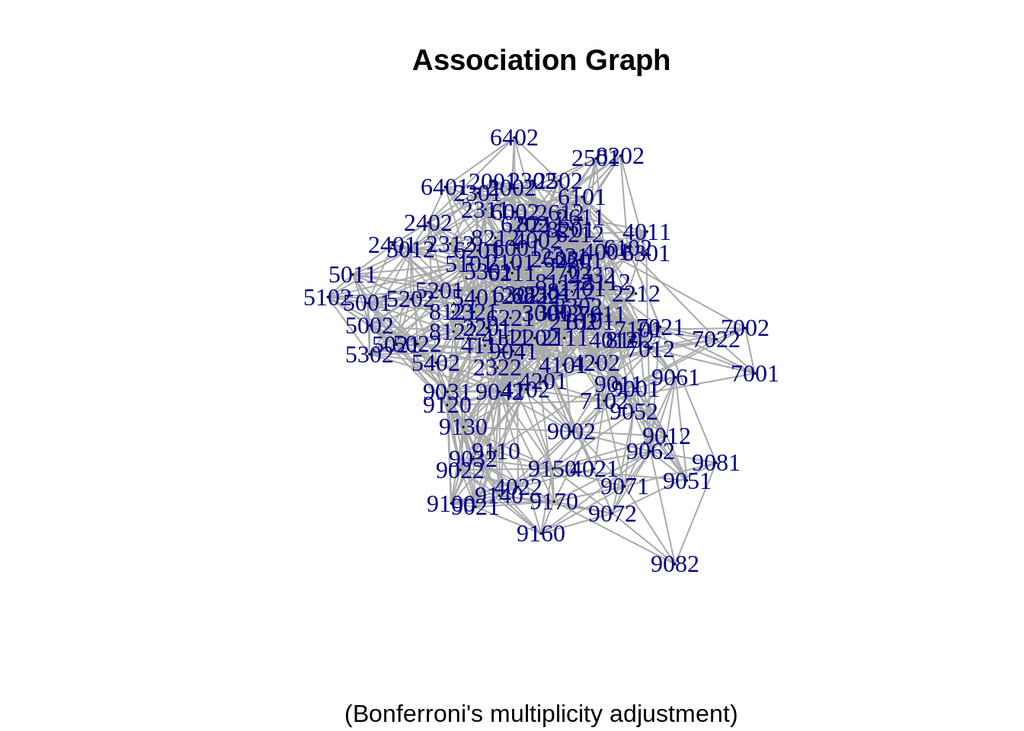

```r
require(igraph, quietly = TRUE)
# Adjacency matrix of the estimated graph with the Bonferroni's correction
adj_mat_bonf <- get.est.adj.mat(asd_sel.dt, check.conf.int, z.t)


# Estimated graph
G.bonf <- graph_from_adjacency_matrix(adj_mat_bonf, mode = "undirected")


# To plot the correlation graph(s)
plot(G.bonf, vertex.size = .5, vertex.color = rgb(0,0,1,.2), label.col = "black", curved = TRUE,
     main = "Association Graph",  sub = "(Bonferroni's multiplicity adjustment)")
```

$$~$$

The association graph taking into only the threshold is:

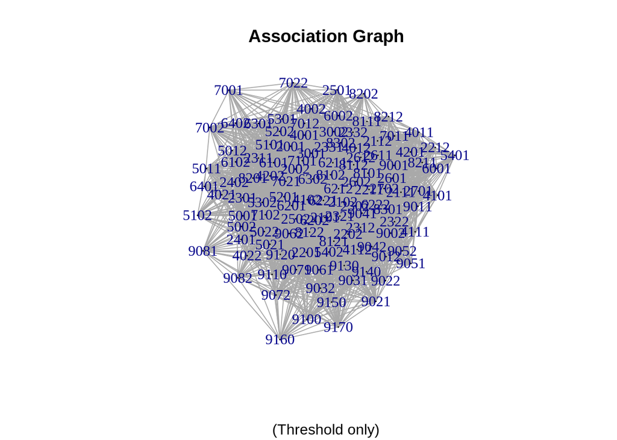

```r
# Adjacency matrix of the estimated graph with the Bonferroni's correction
adj_mat_thr <- get.est.adj.mat(asd_sel.dt, check.threshold, z.t)


# Estimated graph
G.thr <- graph_from_adjacency_matrix(adj_mat_thr, mode = "undirected")


plot(G.thr, vertex.size = .5, vertex.color = rgb(0,0,1,.2), label.col = "black", curved = TRUE,
     main = "Association Graph",  sub = "(Threshold only)")
```

$$~$$

The association graph taking into account the confidence interval without the Bonferroni’s correction is:

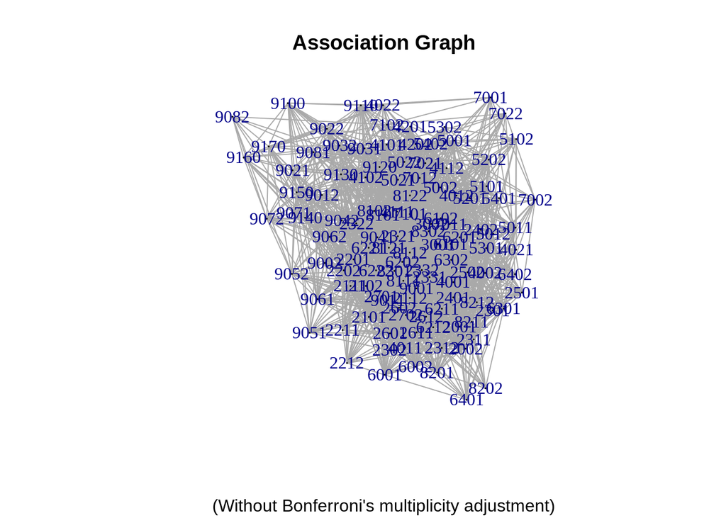

```r
# Recompute the confidence intervals without the multiplicity adjustment
asd_sel.dt$cint <- conf.int(asd_sel.dt, m = 1)


# Adjacency matrix of the estimated graph with the Bonferroni's correction
adj_mat_no_bonf <- get.est.adj.mat(asd_sel.dt, check.conf.int, z.t)


# Estimated graph
G.no.bonf <- graph_from_adjacency_matrix(adj_mat_no_bonf, mode = "undirected")


plot(G.no.bonf, vertex.size = .5, vertex.color = rgb(0,0,1,.2), label.col = "black", curved = TRUE,
     main = "Association Graph",  sub = "(Without Bonferroni's multiplicity adjustment)")
```

$$~$$

Let’s check the number of edges of the estimated ASD graph:

```r
paste("Number of edges considering only the threshold t:", gsize(G.thr))
```

```
## [1] "Number of edges considering only the threshold t: 2851"
```

```r
paste("Number of edges with Bonferroni's correction:", gsize(G.bonf))
```

```
## [1] "Number of edges with Bonferroni's correction: 996"
```

```r
paste("Number of edges without Bonferroni's correction:", gsize(G.no.bonf))
```

```
## [1] "Number of edges without Bonferroni's correction: 1840"
```